# Homework 3

Group-3 Members: Asha Shah | Prabhath Pasula | Rithwik Reddy Nandyala

April , 2025

# Question 1: Student Performance Data

## Part (a): Formulate a Question

**Question**: How do `Hours Studied`, `Previous Scores`, `Extracurricular Activities`, `Sleep Hours`, and `Sample Question Papers Practiced` predict a student’s performance (`Performance Index`)?  
- **Predictor Variables**: `Hours Studied`, `Previous Scores`, `Extracurricular Activities`, `Sleep Hours`, `Sample Question Papers Practiced`  
- **Target Variable**: `Performance Index`

## Part (b): Split Data into Training and Test Sets

```r
# Load the data
student_data <- read.csv("student_performance.csv")

# Convert categorical variables to factors
student_data$Extracurricular.Activities <- as.factor(student_data$Extracurricular.Activities)

# Split into training (70%) and test (30%) sets
set.seed(123)
train_index <- sample(1:nrow(student_data), 0.7 * nrow(student_data))
train_data <- student_data[train_index, ]
test_data <- student_data[-train_index, ]
```

## Part (c): Train a Multiple Linear Regression Model with 10-Fold Cross-Validation

```r
# Train the model using 10-fold cross-validation
set.seed(123)
student_model <- train(
  Performance.Index ~ Hours.Studied + Previous.Scores + Extracurricular.Activities +
    Sleep.Hours + Sample.Question.Papers.Practiced,
  data = train_data,
  method = "lm",
  trControl = trainControl(method = "cv", number = 10, verboseIter = TRUE)
)
# Summary of the model
summary(student_model)
```

```
##
## Call:
## lm(formula = .outcome ~ ., data = dat)
##
## Residuals:
##     Min      1Q  Median      3Q     Max
## -7.5864 -1.3743 -0.0113  1.3400  8.3193
##
## Coefficients:
##                                    Estimate Std. Error t value Pr(>|t|)
## (Intercept)                      -34.047166   0.153166 -222.29   <2e-16 ***
## Hours.Studied                      2.850817   0.009516  299.57   <2e-16 ***
## Previous.Scores                    1.018021   0.001417  718.59   <2e-16 ***
## Extracurricular.ActivitiesYes      0.571091   0.049192   11.61   <2e-16 ***
## Sleep.Hours                        0.488381   0.014501   33.68   <2e-16 ***
## Sample.Question.Papers.Practiced   0.190325   0.008575   22.20   <2e-16 ***
## ---
## Signif. codes:  0 '***' 0.001 '**' 0.01 '*' 0.05 '.' 0.1 ' ' 1
##
## Residual standard error: 2.056 on 6994 degrees of freedom
## Multiple R-squared:  0.9885, Adjusted R-squared:  0.9885
## F-statistic: 1.205e+05 on 5 and 6994 DF,  p-value: < 2.2e-16
```

### Interpretation of Coefficients

Hours Studied: Coefficient: β1 For every additional hour studied, the performance index increases by approximately 2.85 units, holding all other variables constant. This indicates that studying more hours has a strong positive impact on performance.

Previous Scores: Coefficient: β2 For each additional unit increase in previous test scores, the performance index increases by approximately 1.02 units, holding all other variables constant. This suggests that past performance is a strong predictor of current performance.

Extracurricular Activities (Yes): Coefficient: β3 Students who participate in extracurricular activities have a performance index that is, on average, 0.57 units higher than those who do not, holding all other variables constant.

Sleep Hours: Coefficient: β4 For every additional hour of sleep, the performance index increases by approximately 0.49 units, holding all other variables constant. This highlights the importance of sleep for academic performance.

Sample Question Papers Practiced: Coefficient: β5 For every additional sample question paper practiced, the performance index increases by approximately 0.19 units, holding all other variables constant. While this effect is smaller, it is still positive and meaningful.

Conclusion: - Hours Studied and Previous Scores have the largest impact on the Performance Index. - Extracurricular Activities, Sleep Hours, and Sample Question Papers Practiced also positively contribute to performance, but their effects are smaller. - The model explains a large portion of the variance in the Performance Index, as indicated by the high R-squared value (R2).

### Fitted Regression Equation

Performance_Index <- -34.047166 + 2.850817 * Hours_Studied + 1.018021 * Previous_Scores + 0.571091 * Extracurricular_ActivitiesYes + 0.488381 * Sleep_Hours + 0.190325 * Sample_Question_Papers_Practiced

## Part (d): Evaluate Model Performance on the Test Set

```r
# Predict on the test set
predictions <- predict(student_model, newdata = test_data)

# Calculate R-squared and RMSE
r_squared <- cor(test_data$Performance.Index, predictions)^2
errors <- predictions - test_data$Performance.Index
rmse <- sqrt(mean(errors^2))

# Print results
cat("R-squared:", r_squared, "\n")
```

```
## R-squared: 0.9892739
```

```r
cat("RMSE:", rmse, "\n")
```

```
## RMSE: 1.995368
```

### Comments on Model Performance

- **R-squared (R^2): 0.9893**
- This indicates that 98.93% of the variance in the Performance Index is explained by the predictor variables in the model.
- A high (R^2) value like this suggests that the model fits the data very well and has strong predictive power.

-**Root Mean Squared Error (RMSE): 1.9954** - The RMSE indicates that, on average, the model’s predictions are about 1.9954 units away from the actual Performance Index values. - Given the scale of the Performance Index (ranging from 10 to 100), this is a very small error, which demonstrates that the model has high accuracy.

Comments: - The high (R^2) value and low RMSE both suggest that the regression model performs exceptionally well on the test set. - The model generalizes well to unseen data, as evidenced by the low prediction error. —

## Part (e): Residual Diagnostics

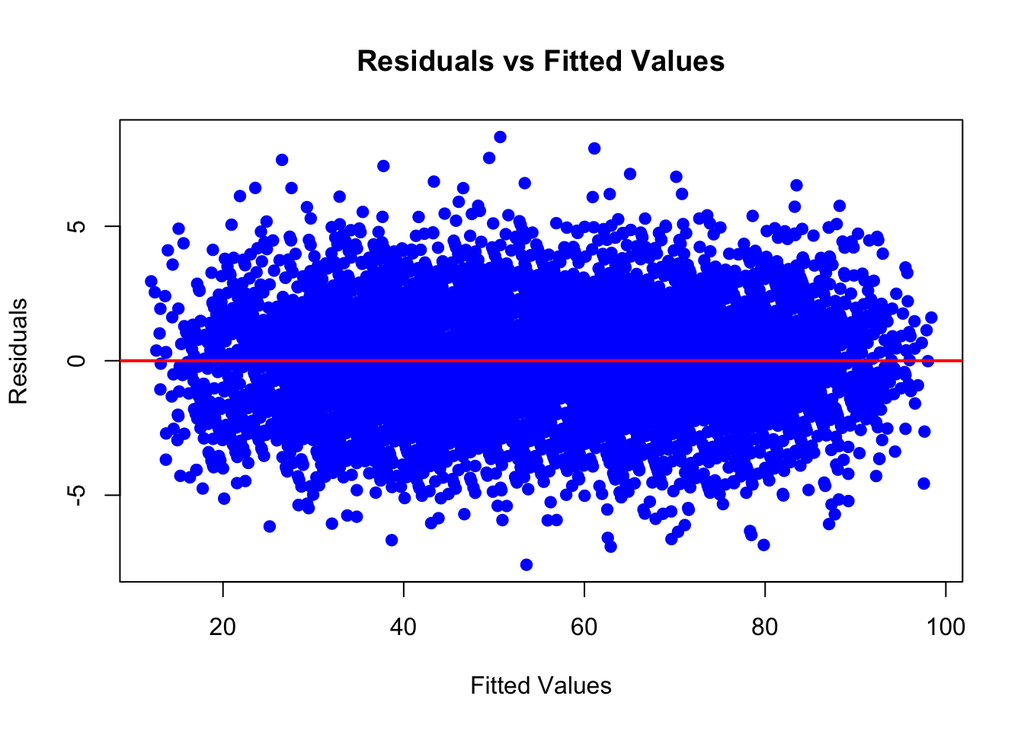

```r
# Extract residuals from the fitted model
residuals <- residuals(student_model$finalModel)

# Residuals vs Fitted Values Plot (Linearity and Homoscedasticity)
plot(fitted(student_model$finalModel), residuals,
     main = "Residuals vs Fitted Values",
     xlab = "Fitted Values",
     ylab = "Residuals",
     pch = 19, col = "blue")
abline(h = 0, col = "red", lwd = 2)
```

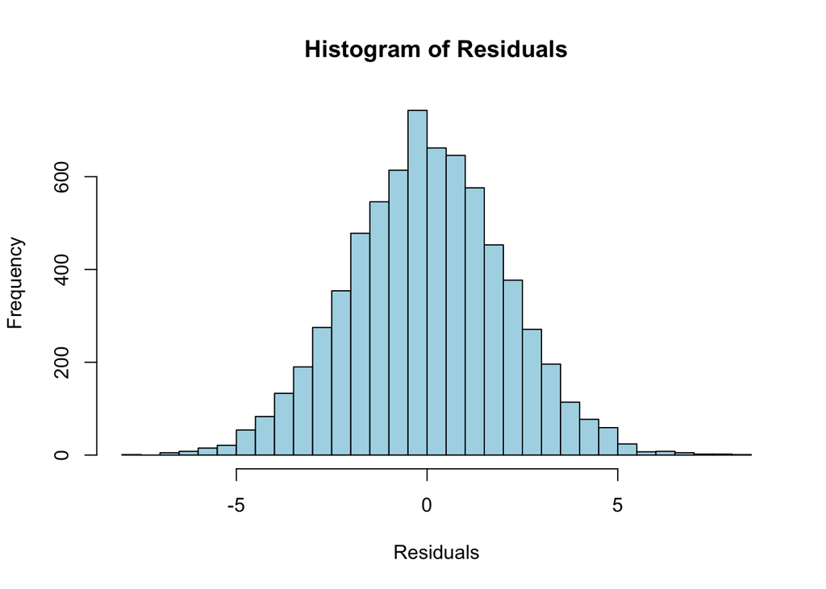

```r
# Histogram of Residuals (Normality)
hist(residuals, main = "Histogram of Residuals",
     xlab = "Residuals", col = "lightblue", breaks = 30)
```

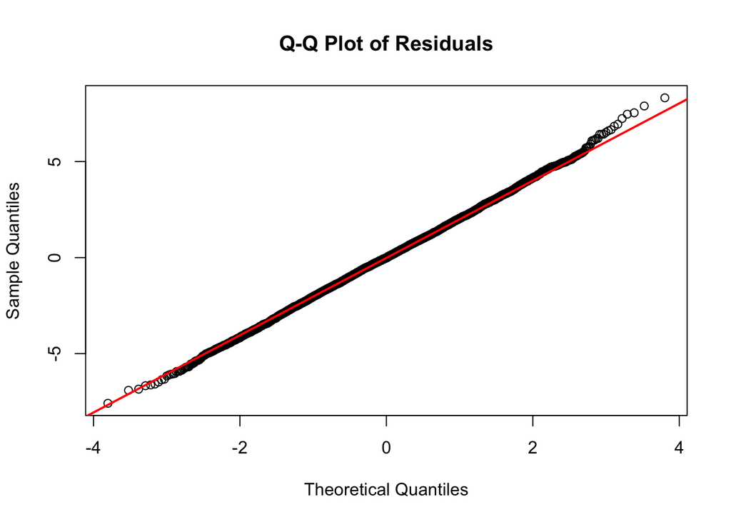

```r
# Q-Q Plot (Normality)
qqnorm(residuals, main = "Q-Q Plot of Residuals")
qqline(residuals, col = "red", lwd = 2)
```

### Comments on Diagnostics

1. Linearity and Homoscedasticity
- The residuals are randomly scattered around the horizontal red line (y=0) without any clear pattern or trend.
- The spread of residuals is relatively constant for all fitted values, indicating no evidence of heteroscedasticity (non-constant variance).

Conclusion: The assumptions of linearity and homoscedasticity are satisfied. The linear regression model is appropriate for the data in terms of these assumptions.

2. Normality of Residuals
- The histogram of residuals closely resembles a bell-shaped curve, indicating that the residuals are symmetrically distributed around 0.
- The Q-Q plot shows that most residuals lie close to the 45-degree red line, suggesting that the residuals follow a normal distribution. Minor deviations at the extremes (tails) are observed but are not significant.

Conclusion: The residuals are approximately normally distributed, satisfying the normality assumption of the linear regression model.

Overall, the diagnostics confirm that the model assumptions are reasonably satisfied, and the regression model is suitable for making predictions and drawing inferences. —

## Part (f): Proposed Interventions

### Proposed Interventions to Improve Student Performance

Based on the insights gained from the analysis, the following interventions are proposed to enhance student performance:

1. **Increase Study Hours**:
   - Since “Hours Studied” has the strongest positive impact on performance, structured study schedules, peer study groups, and study-time tracking tools should be introduced to encourage students to dedicate more time to studying.
2. **Target Low-Performing Students**:
   - “Previous Scores” are a strong predictor of performance. Students with low prior scores should be identified and offered remedial programs, tutoring, or personalized learning plans.
3. **Promote Extracurricular Activities**:
   - Participation in extracurricular activities has a positive effect on performance. Schools should encourage students to engage in such activities to foster holistic development and improve academic outcomes.
4. **Encourage Healthy Sleep Habits**:
   - Proper sleep is crucial for cognitive functioning and performance. Awareness campaigns and student counseling can help students adopt healthier sleep patterns.
5. **Increase Practice with Sample Papers**:
   - Practicing more sample question papers helps familiarize students with exam formats and reduces test anxiety. Schools should provide additional resources and time for mock exams.

### Addressing Minor Assumption Violations

While the model assumptions are largely satisfied, there are minor deviations in the Q-Q plot at the tails, indicating potential outliers or slight non-normality. Remedies include:

- **Handling Outliers**:
  - Investigate the data points contributing to the deviations. If necessary, apply robust regression techniques or data transformations (e.g., log or square root) to minimize their impact.
- **Improving Model Complexity**:
  - If additional non-linear relationships are suspected, consider adding polynomial or interaction terms to capture more complex patterns in the data.

Through these targeted interventions and minor refinements, student performance can be further improved, while maintaining a robust and reliable regression model. —

# Question 2: Loan Status Prediction

## Part (a): Split Data into Training and Test Sets

```r
# Load the data
loan_data <- read.csv("loan_data.csv")

# Print column names
colnames(loan_data)
```

```
##  [1] "Loan_ID"           "Gender"            "Married"
##  [4] "Dependents"        "Education"         "Self_Employed"
##  [7] "ApplicantIncome"   "CoapplicantIncome" "LoanAmount"
## [10] "Loan_Amount_Term"  "Credit_History"    "Property_Area"
## [13] "Loan_Status"
```

```r
# Convert categorical variables to factors
loan_data$Gender <- as.factor(loan_data$Gender)
loan_data$Married <- as.factor(loan_data$Married)
loan_data$Education <- as.factor(loan_data$Education)
loan_data$Self_Employed <- as.factor(loan_data$Self_Employed)
loan_data$Property_Area <- as.factor(loan_data$Property_Area)
loan_data$Loan_Status <- as.factor(loan_data$Loan_Status)

# Handle missing values
loan_data$LoanAmount[is.na(loan_data$LoanAmount)] <- median(loan_data$LoanAmount, na.rm = TRUE)
loan_data$Loan_Amount_Term[is.na(loan_data$Loan_Amount_Term)] <- median(loan_data$Loan_Amount_Term, na.rm = TRUE)
loan_data$Credit_History[is.na(loan_data$Credit_History)] <- median(loan_data$Credit_History, na.rm = TRUE)
loan_data$Gender[is.na(loan_data$Gender)] <- as.factor("Missing")
loan_data$Married[is.na(loan_data$Married)] <- as.factor("Missing")
loan_data$Dependents[is.na(loan_data$Dependents)] <- as.factor("0")
loan_data$Self_Employed[is.na(loan_data$Self_Employed)] <- as.factor("No")

# Split into training (80%) and test (20%) sets
set.seed(123)
train_index <- sample(1:nrow(loan_data), 0.8 * nrow(loan_data))
train_data <- loan_data[train_index, ]
test_data <- loan_data[-train_index, ]
```

## Part (b): Train Logistic Regression Model

```r
# Train the logistic regression model
train_control <- trainControl(
  method = "cv",
  number = 10,
  classProbs = TRUE,
  summaryFunction = twoClassSummary
)

loan_model <- train(
  Loan_Status ~ Gender + Married + Dependents + Education + Self_Employed +
    ApplicantIncome + CoapplicantIncome + LoanAmount + Loan_Amount_Term +
    Credit_History + Property_Area,
  data = train_data,
  method = "glm",
  family = binomial,
  trControl = train_control,
  metric = "ROC"
)


# Summary of the model
summary(loan_model)
```

```
##
## Call:
## NULL
##
## Coefficients:
##                           Estimate Std. Error z value Pr(>|z|)
## (Intercept)             -3.244e+00  2.770e+00  -1.171  0.24160
## GenderFemale             5.884e-01  1.924e+00   0.306  0.75971
## GenderMale               9.461e-01  1.914e+00   0.494  0.62116
## MarriedYes               1.714e-01  4.145e-01   0.413  0.67928
## Dependents0              7.334e-01  1.091e+00   0.672  0.50139
## Dependents1              1.140e-01  1.134e+00   0.101  0.91993
## Dependents2              3.823e-01  1.155e+00   0.331  0.74065
## `Dependents3+`           4.310e-01  1.234e+00   0.349  0.72691
## `EducationNot Graduate` -5.438e-01  3.868e-01  -1.406  0.15971
## Self_EmployedNo         -8.284e-01  9.527e-01  -0.870  0.38457
## Self_EmployedYes        -1.146e+00  1.056e+00  -1.086  0.27761
## ApplicantIncome         -1.664e-04  1.315e-04  -1.266  0.20554
## CoapplicantIncome       -6.450e-05  5.492e-05  -1.174  0.24021
## LoanAmount               1.213e-02  6.402e-03   1.895  0.05805 .
## Loan_Amount_Term        -3.585e-03  2.894e-03  -1.239  0.21531
## Credit_History           4.667e+00  6.731e-01   6.934  4.1e-12 ***
## Property_AreaSemiurban   1.224e+00  4.587e-01   2.667  0.00764 **
## Property_AreaUrban       1.257e-01  4.290e-01   0.293  0.76953
## ---
## Signif. codes:  0 '***' 0.001 '**' 0.01 '*' 0.05 '.' 0.1 ' ' 1
##
## (Dispersion parameter for binomial family taken to be 1)
##
##     Null deviance: 352.45  on 303  degrees of freedom
## Residual deviance: 227.99  on 286  degrees of freedom
## AIC: 263.99
##
## Number of Fisher Scoring iterations: 5
```

## Part (c): Evaluate Model Performance on the Test Set

```r
# Predict on the test set
predictions <- predict(loan_model, newdata = test_data)
probabilities <- predict(loan_model, newdata = test_data, type = "prob")[, "Y"]

# Confusion matrix
conf_matrix <- confusionMatrix(predictions, test_data$Loan_Status, positive = "Y")

# Metrics
cat("Accuracy:", conf_matrix$overall["Accuracy"], "\n")
```

```
## Accuracy: 0.8051948
```

```r
cat("Sensitivity:", conf_matrix$byClass["Sensitivity"], "\n")
```

```
## Sensitivity: 1
```

```r
cat("Specificity:", conf_matrix$byClass["Specificity"], "\n")
```

```
## Specificity: 0.4827586
```

```r
# AUC
test_data$Loan_Status_numeric <- ifelse(test_data$Loan_Status == "Y", 1, 0)
roc_curve <- roc(test_data$Loan_Status_numeric, probabilities)
auc_value <- auc(roc_curve)
cat("AUC:", auc_value, "\n")
```

```
## AUC: 0.8017241
```

### Comments on Model Performance

- **Accuracy**: Indicates that 80.5% of the predictions made by the model are correct, showing reasonably good overall performance.
- **Sensitivity**: The model perfectly predicts approved loans (100%), meaning it correctly identifies all positive cases.
- **Specificity**: At 48.3%, the model struggles to correctly predict denied loans, leading to a higher rate of false positives.
- **AUC**: With a value of 0.802, the model exhibits good discriminatory power in distinguishing approved from denied loans, though there is room for improvement. —